# Sales Analysis for an E-commerce Website

## Project Overview:

1. **Data Exploration** - Entity relationship diagrams
2. **Data Cleaning** - Remove duplication and cleansing process
3. **Data Analysing** - Answering the business questions
4. **Data Visualization** - Matplot in python
5. **Documentation** - jupyter notebook

## Database Details:

1. **Customers**: Contains information about the customers, including customer ID, first name, lastname,city, country phone and number.
2. **Products**: Contains information about the products sold on the website, including product ID, product name, supplierid, package, isdisconnected and unitprice.
3. **Orders**: Contains information about the orders placed by customers, including order ID, customer ID, order date, and total amount and order number.
4. **Order_Items**: Contains information about the items included in each order, including order ID, product ID, quantity, and price

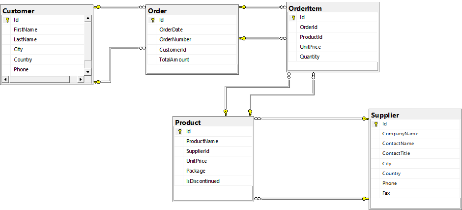

# Project Tasks:

## 1. Data Exploration

This database has the detailed information about the Ecommerce websites with complete **products, customer and order details**.

## 2. Data Cleansing

Data cleansing process involved in this project are:

1. Removing Duplicates
2. Removing leading and trailing spaces
3. Converting data types
4. Handling missing values
5. Standardizing values
6. Handling outliers

## Removing Duplicates

**Cleansing process in [dbo].[Customer] table**

- Dropped the column name "supplierid" in customer table.

```
ALTER TABLE [dbo].[Customer]
DROP COLUMN supplierid;
```

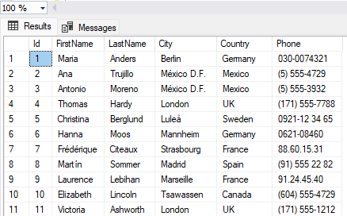

- Combining the "FirstName" and "LastName" to get "FullName" to make sure the data integrity.

```
ALTER TABLE [dbo].[Customer]
ADD FullName VARCHAR(100);
```

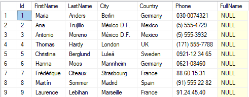

- Concating the both values. [FirstName + LastName = FullName].

```
UPDATE [dbo].[Customer]
SET [FullName] = [FirstName] + ' ' +  [LastName];
```

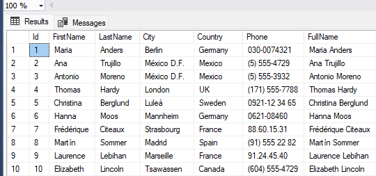

- Checking for duplicate values in the rows of all each columns.

```
1.
DELETE FROM [dbo].[Customer]
WHERE Id IN (
    SELECT Id
    FROM [dbo].[Customer]
    GROUP BY Id
    HAVING COUNT(*) > 1
);

2.
DELETE FROM [dbo].[Customer]
WHERE FullName IN (
    SELECT FullName
    FROM [dbo].[Customer]
    GROUP BY FullName
    HAVING COUNT(*) > 1
);

3.
DELETE FROM [dbo].[Customer]
WHERE Phone IN (
    SELECT Phone
    FROM [dbo].[Customer]
    GROUP BY Phone
    HAVING COUNT(*) > 1
);
```

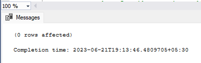

**Cleansing process in [dbo].[Order] table**

- Checked for duplicates in order table in ID and OrderNumber column

```
DELETE FROM [dbo].[Order]
WHERE id IN (
    SELECT id
    FROM [dbo].[Order]
    GROUP BY id
    HAVING COUNT(*) > 1
);

DELETE FROM [dbo].[Order]
WHERE OrderNumber IN (
    SELECT OrderNumber
    FROM [dbo].[Order]
    GROUP BY OrderNumber
    HAVING COUNT(*) > 1
);
```

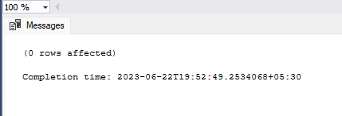

**Cleansing process in [dbo].[OrderItem] table**

- Checked for duplicates in orderitem table in ID column.

```
DELETE FROM [dbo].[OrderItem]
WHERE Id IN (
    SELECT Id
    FROM [dbo].[OrderItem]
    GROUP BY Id
    HAVING COUNT(*) > 1
);
```

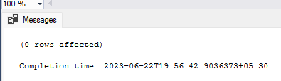

**Cleansing process in [dbo].[Product] table.**

- Checked for duplicates in Product table in ID column.

```
DELETE FROM [dbo].[Product]
WHERE Id IN (
    SELECT Id
    FROM [dbo].[Product]
    GROUP BY Id
    HAVING COUNT(*) > 1
);
```

```
DELETE FROM [dbo].[Product]
WHERE ProductName IN (
    SELECT ProductName
    FROM [dbo].[Product]
    GROUP BY ProductName
    HAVING COUNT(*) > 1
);
```

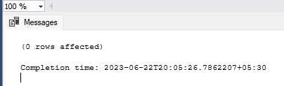

**Note**: Not supposed to perform remove duplicate in all column.  
**Example**: CustomerId in Order table. Single customer can order multiple items so we can't perform this action.

## Removing leading and trailing spaces

It will applicable all the columns so queried with common SQL commands

Example: Trimmed the FullName column and 91 rows got affected.

```
UPDATE [dbo].[Customer]
SET FullName = TRIM(FullName);
```

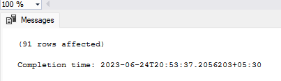

## Converting data types

Checking and verifying the Data types of the all tables.

```
SELECT COLUMN_NAME, DATA_TYPE
FROM INFORMATION_SCHEMA.COLUMNS;
```

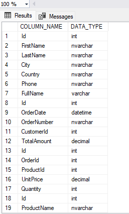

**Verified that all columns of the tables has appropiate data types.**

## Handling missing values

- Tables order and products has missing and null values.
- In order table has FK_ORDERITE_REFERENCE_ORDER constraints.
- STATUSS column is removed and 79 id in Product has empty values also deleted.

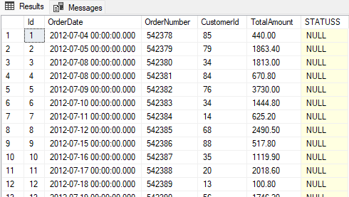

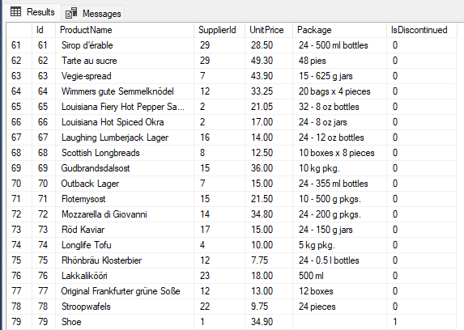

```
DELETE FROM [dbo].[Order]
WHERE STATUSS IS NULL;
DELETE FROM [dbo].[Product]
WHERE Package = '';
```

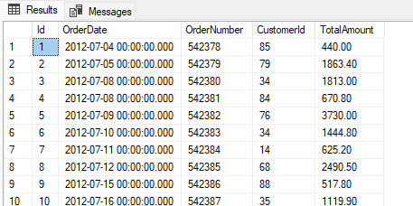

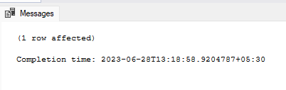

## Standardizing values

In customers table Country values are standarded.

```
UPDATE [dbo].[Customers]
SET Country = UPPER('USA')
WHERE Country = LOWER('usa')
UPDATE [dbo].[Customers]
SET Country = UPPER('UK')
WHERE Country = LOWER('uk')
```

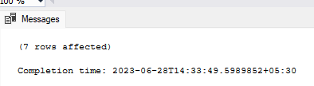

## Handling outliers

- **Note:** No outliers is detected from this ecommerceDB database.

# 3. Data Analysing

**Clients Requirements**

*1. What are the total sales revenue and the total number of orders for each month?*

**Analysis**: Revenue and total orders are analysed from the [dbo].[Order]

**Required result** : Date, Total sales per month and Total no.of orders.

**SQL Queries**:

```
SELECT
    FORMAT(OrderDate, 'yyyy-MM') AS 'Date by Month',
    SUM(TotalAmount) AS 'Total Revenue',
    COUNT(*) AS 'Number of Orders'
FROM
    [dbo].[Order]
GROUP BY
    FORMAT(OrderDate, 'yyyy-MM');
```

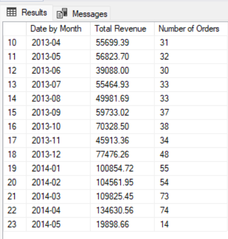

### Data Visualization - Visual implementation

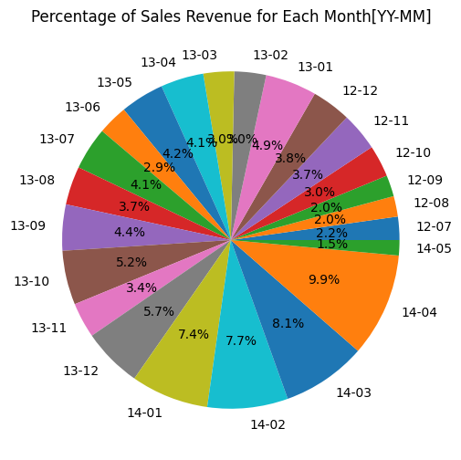

```
On 2014-04 has the highest sales revenue has been analyzed
```

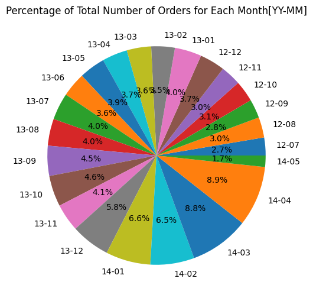

```
On 2014-04 has the highest number of orders has been analyzed
```

```python
import matplotlib.pyplot as plt

months = ['12-07', '12-08', '12-09', '12-10', '12-11', '12-12', '13-01', '13-02', '13-03', '13-04', '13-05', '13-06', '13-07', '13-08', '13-09', '13-10', '13-11', '13-12', '14-01', '14-02', '14-03', '14-04', '14-05']
revenue = [30192.10, 26609.40, 27636.00, 41203.60, 49704.00, 50953.40, 66692.80, 41207.20, 39979.90, 55699.39, 56823.70, 39088.00, 55464.93, 49981.69, 59733.02, 70328.50, 45913.36, 77476.26, 100854.72, 104561.95, 109825.45, 134630.56, 19898.66]
orders = [22, 25, 23, 26, 25, 31, 33, 29, 30, 31, 32, 30, 33, 33, 37, 38, 34, 48, 55, 54, 73, 74, 14]

# Pie chart for total sales revenue
plt.figure(figsize=(8, 6))
plt.pie(revenue, labels=months, autopct='%1.1f%%')
plt.title('Percentage of Sales Revenue for Each Month[YY-MM]')
plt.show()

print("On 2014-04 has the highest sales revenue has been analyzed")

# Pie chart for total number of orders
plt.figure(figsize=(8, 6))
plt.pie(orders, labels=months, autopct='%1.1f%%')
plt.title('Percentage of Total Number of Orders for Each Month[YY-MM]')
plt.show()

print("On 2014-04 has the highest number of orders has been analyzed")
```

*2. What are the top 5 best-selling products in terms of quantity and revenue?*

**SQL Queries**:

```
SELECT
    TOP 5 P.ProductName,
    OI.ProductId,
    SUM(OI.Quantity) AS 'Quantity',
    SUM(O.TotalAmount) AS 'Revenue'
FROM
    [dbo].[Order] O
INNER JOIN
    [dbo].[OrderItem] OI ON OI.OrderId = O.Id
INNER JOIN
    [dbo].[Product] P ON P.Id = OI.ProductId
GROUP BY
    P.ProductName,
    OI.Quantity,
    OI.ProductId, O.Id
ORDER BY
    OI.Quantity DESC,
    SUM(O.TotalAmount) DESC;
```

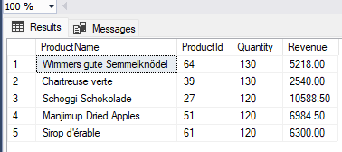

### Data Visualization - Visual implementation

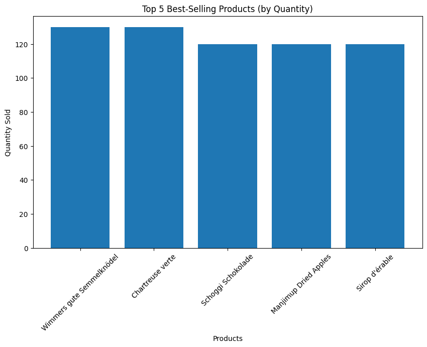

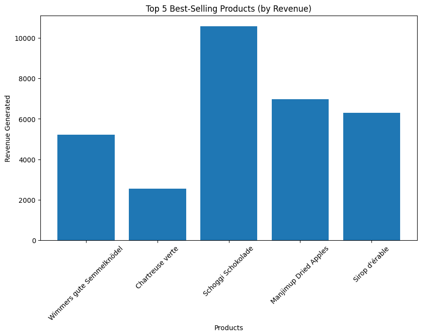

```python
import matplotlib.pyplot as plt

# Sample data (replace with your actual query results)
products = ['Wimmers gute Semmelknödel',
'Chartreuse verte',
'Schoggi Schokolade',
'Manjimup Dried Apples',
"Sirop d'érable"]
quantity_sold = [130,
130,
120,
120,
120]
revenue_generated = [5218.00,
2540.00,
10588.50,
6984.50,
6300.00]

# Plotting the top 5 best-selling products by quantity
plt.figure(figsize=(10, 6))
plt.bar(products, quantity_sold)
plt.xlabel('Products')
plt.ylabel('Quantity Sold')
plt.title('Top 5 Best-Selling Products (by Quantity)')
plt.xticks(rotation=45)
plt.show()

# Plotting the top 5 best-selling products by revenue
plt.figure(figsize=(10, 6))
plt.bar(products, revenue_generated)
plt.xlabel('Products')
plt.ylabel('Revenue Generated')
plt.title('Top 5 Best-Selling Products (by Revenue)')
plt.xticks(rotation=45)
plt.show()
```

*3. Who are the top 10 customers in terms of total spending?*

**Analysis**: Total spending are analysed from the [dbo].[Order] and [dbo].[Customers]

**Required result** : Id, Customer Name and Total Amounts.

**SQL Queries**:

```
SELECT
    TOP 10 C.Id,
    C.FullName AS 'Customer Name',
    SUM(O.TotalAmount) AS 'Total Amount'
FROM
    [dbo].[Customers] C
INNER JOIN
    [dbo].[Order] O ON O.CustomerId = C.Id
GROUP BY
     C.Id, C.FullName
ORDER BY
    SUM(O.TotalAmount) DESC;
```

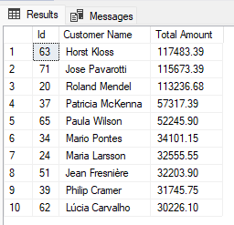

### Data Visualization - Visual implementation

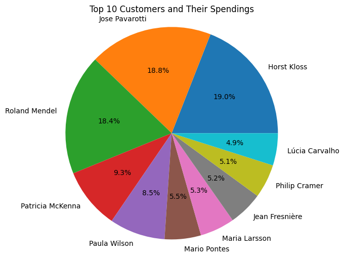

```python
import matplotlib.pyplot as plt

customerName = ['Horst Kloss', 'Jose Pavarotti', 'Roland Mendel', 'Patricia McKenna', 'Paula Wilson', 'Mario Pontes', 'Maria Larsson', 'Jean Fresnière', 'Philip Cramer', 'Lúcia Carvalho']
totalRevenue = [117483.39, 115673.39, 113236.68, 57317.39, 52245.90, 34101.15, 32555.55, 32203.90, 31745.75, 30226.10]

plt.figure(figsize=(8, 6))
plt.pie(totalRevenue, labels=customerName, autopct='%1.1f%%')
plt.title('Top 10 Customers and Their Spendings')
plt.axis('equal')
plt.show()
```

*4. What is the average order value for each month?*

**Analysis**: Average order values are analysed from the [dbo].[Order]

**Required result** : Date by Month and Average Values.

**SQL Queries:**

```
SELECT
    FORMAT(OrderDate, 'yyyy-MM') AS 'Date by Month',
    AVG(TotalAmount) AS 'Average Values'
FROM
    [dbo].[Order]
GROUP BY
    FORMAT(OrderDate, 'yyyy-MM');
```

[figure not shown]

### Data Visualization - Visual implementation

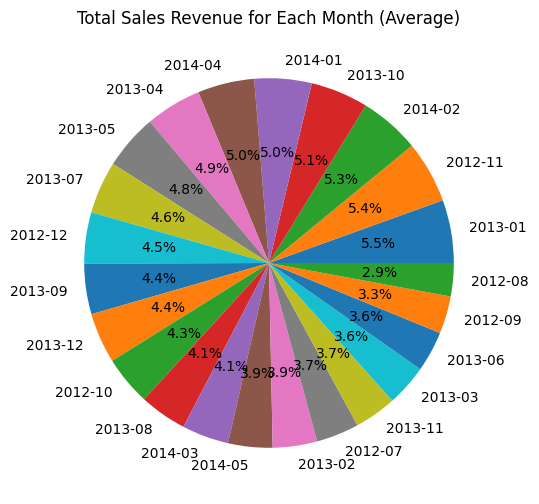

```python
import matplotlib.pyplot as plt

date = ['2013-01', '2012-11', '2014-02', '2013-10', '2014-01', '2014-04', '2013-04', '2013-05', '2013-07', '2012-12', '2013-09', '2013-12', '2012-10', '2013-08', '2014-03', '2014-05', '2013-02', '2012-07', '2013-11', '2013-03', '2013-06', '2012-09', '2012-08']
avg = [2020.993939, 1988.16, 1936.332407, 1850.75, 1833.722181, 1819.331891, 1796.754516, 1775.740625, 1680.755454, 1643.658064, 1614.405945, 1614.08875, 1584.753846, 1514.596666, 1504.458219, 1421.332857, 1420.937931, 1372.368181, 1350.392941, 1332.663333, 1302.933333, 1201.565217, 1064.376]

plt.figure(figsize=(8, 6))
plt.pie(avg, labels=date, autopct='%1.1f%%')
plt.title('Total Sales Revenue for Each Month (Average)')
plt.show()
```

*5. What is the customer retention rate for the given period (e.g. month, quarter, year)?*

**Analysis**: customer retention rate are analysed from the [dbo].[Order]

**SQL Queries:**

```
SELECT
    COUNT(DISTINCT retained_customers.CustomerID) AS RetainedCustomers,
    COUNT(DISTINCT all_customers.CustomerID) AS TotalCustomers,
    CASE WHEN COUNT(DISTINCT all_customers.CustomerID) > 0
         THEN CAST(COUNT(DISTINCT retained_customers.CustomerID) AS FLOAT) / COUNT(DISTINCT all_customers.CustomerID)
         ELSE 0
    END AS RetentionRate
FROM
    (
        SELECT CustomerID
        FROM [dbo].[Order]
        WHERE OrderDate >= @StartDate AND OrderDate <= @EndDate
    ) AS retained_customers
INNER JOIN
    (
        SELECT CustomerID
        FROM [dbo].[Order]
        WHERE OrderDate < @StartDate
    ) AS all_customers
ON retained_customers.CustomerID = all_customers.CustomerID;
```

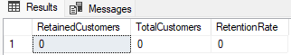

*6. Which category of products generates the highest revenue?*

**Analysis**: highest revenue are analysed from the [dbo].[OrderItem] and [dbo].[Product]

**Required result** : ProductName and TotalRevenue.

**SQL Queries:**

```
SELECT
    TOP 1
    P.ProductName,
    SUM(OI.Quantity * OI.UnitPrice) AS TotalRevenue
FROM
    Product P
    INNER JOIN OrderItem OI ON P.ID = OI.ProductID
GROUP BY
    P.ProductName
ORDER BY
    TotalRevenue DESC;
```

### Data Visualization - Visual implementation

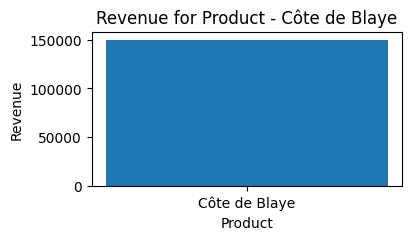

```python
import matplotlib.pyplot as plt

product = ['Côte de Blaye']
revenue = [149984.20]

plt.figure(figsize=(4, 2))
plt.bar(product, revenue)
plt.xlabel('Product')
plt.ylabel('Revenue')
plt.title('Revenue for Product - Côte de Blaye')
plt.show()
```

[GitHub Repository](https://github.com/idevmou/Sales-Analysis-for-an-E-commerce-Website) [Download](https://github.com/idevmou/Sales-Analysis-for-an-E-commerce-Website/archive/refs/heads/main.zip)